# Data Analysis Report Study 1

Niklas Johannes

25/11/2019

```r
# pacman makes it easier to load and install packages
if (!requireNamespace("pacman"))
  install.packages("pacman")

library(pacman)

# load packages
p_load(
  here,
  janitor,
  pastecs,
  betareg,
  car,
  lattice,
  cowplot,
  lme4,
  afex,
  DHARMa,
  emmeans,
  MuMIn,
  tidyverse
)

# set seed
set.seed(42)

# set theme
theme_set(theme_cowplot())
```

```r
### FUNCTION 1 ###
# little function that describes and visualizes variables, either for repeated-measures or trait-like
describe_visualize <-
  function(df,
           variable,
           repeated_measure = FALSE,
           want_summary = FALSE){

    variable <- enquo(variable)

    # specifies whether the variable we want to plot is a trait-like or repeated measure
    if (repeated_measure == FALSE){
      df <-
        df %>%
        group_by(food) %>%
        slice(1) %>%
        ungroup()
    } else {
      df <-
        df
    }

    # descriptive stats
    sum_stats <-
      df %>%
      pull(!! variable) %>%
      stat.desc()

    # plot
    plot <-
      ggplot(df, aes(x = !! variable)) +
        geom_density(color = "darkgrey", fill = "darkgrey") +
        geom_point(aes(x = !! variable, y = 0))

    # return the two (if both are wanted)
    if(want_summary == TRUE){
      return(list(knitr::kable(sum_stats), plot))
    } else{
      return(plot)
    }
  }

### FUNCTION 2 ###
# function to produce violin plots for a variable for each food type
three_violins <-
  function(
    df,
    variable
  ){

    variable <- enquo(variable)

    df <-
      df %>%
      group_by(food) %>%
      slice(1) %>%
      ungroup()

    ggplot(
      df,
      aes(
        x = food_type,
        y = !! variable,
        color = food_type,
        fill = food_type
      )
    ) +
      geom_violin() +
      scale_color_brewer(palette = "Dark2") +
      scale_fill_brewer(palette = "Dark2")
  }

### FUNCTION 3###
# provides summary statistics for a variable for each food type
summary_stats <-
  function(
    df,
    variable
  ){
    variable <- enquo(variable)

    summary_stats <-
      df %>%
      group_by(food_type) %>%
      summarize(mean = mean(!! variable),
                sd = sd(!! variable))

    summary_stats
  }
```

# 1. Load data and wrangle data

```r
raw_data <- read_csv(
  here("data", "study1", "raw_data.csv")
  )
```

The variable names aren’t in a nice format. Notably, they all contain `_all_items_final` at the end and are in all upper case. I will first remove the `_all_items_final` part from the variable names and then use the `janitor` package to get nicer variable names.

```r
# use a working file from now on
working_file <- raw_data

# remove variable name part
names(working_file) <-
  names(working_file) %>%
  str_remove(., "_all_items_final")

# get variable names in snake case
working_file <-
  clean_names(working_file)

# inspect data
glimpse(working_file)
```

```
## Observations: 240
## Variables: 46
## $ subjectnr              <dbl> 1, 2, 3, 4, 5, 6, 7, 8, 9, 10, 11, 12, ...
## $ production             <dbl> 1, 0, 1, 1, 1, 0, 0, 0, 5, 2, 0, 0, 2, ...
## $ package                <dbl> 0, 0, 0, 0, 0, 0, 0, 0, 0, 0, 0, 0, 0, ...
## $ purchase_accessibility <dbl> 0, 0, 0, 0, 0, 0, 0, 0, 0, 0, 0, 0, 0, ...
## $ prep_stor              <dbl> 1, 0, 0, 0, 0, 0, 0, 0, 0, 0, 0, 0, 0, ...
## $ ingred_cont            <dbl> 7, 2, 2, 5, 5, 1, 0, 0, 1, 1, 3, 0, 5, ...
## $ visual                 <dbl> 0, 0, 0, 0, 1, 0, 0, 0, 0, 0, 0, 0, 0, ...
## $ long_ter_pos           <dbl> 0, 0, 0, 0, 0, 0, 0, 0, 0, 0, 0, 0, 0, ...
## $ long_ter_neg           <dbl> 0, 0, 0, 0, 0, 0, 0, 0, 0, 0, 0, 0, 0, ...
## $ cult_embed             <dbl> 0, 1, 0, 0, 0, 0, 0, 0, 0, 0, 0, 0, 0, ...
## $ overall_pos_eval       <dbl> 0, 0, 1, 0, 0, 0, 1, 0, 1, 0, 0, 0, 0, ...
## $ overall_neg_eval       <dbl> 0, 0, 0, 0, 0, 0, 0, 0, 0, 0, 0, 0, 0, ...
## $ other                  <dbl> 0, 0, 0, 0, 0, 0, 0, 0, 0, 0, 0, 0, 0, ...
```

[output cut: 33 more lines]

Next, I add a food type category based on the subject number (`subjectnr` indicates the food ID):

- 1-80: vegan
- 81-160: vegetarian
- 161-240: meat-based

```r
working_file <-
  working_file %>%
  mutate(
    food_type = case_when(
      subjectnr %in% 1:80 ~ "vegan",
      subjectnr %in% 81:160 ~ "vegetarian",
      subjectnr %in% 161:240 ~ "meat_based"
    )
  ) %>%
  rename( # give more sensible name for food ID
    "food_id" = "subjectnr"
  )
```

At this point, we also don’t have the actual food names in the data set. Although we don’t necessarily need them in the analysis, I’ll add them for completeness’ sake. In addition, the file also has the supermarkets that belong to each food, and I’ll need those for analysis.

The food label data set is in the long format, meaning I first need to get unique food names, then add them to working file.

```r
# read the file with food names and features
food_labels <-
  read_csv(
    here("data", "study1", "food_labels.csv")
  )

head(food_labels)
```

```
## # A tibble: 6 x 4
##   food                                     feature_no feature   supermarket
##   <chr>                                         <dbl> <chr>     <chr>
## 1 punjab_pakora_vegetable_pakora_with_tom~          1 delicious A
## 2 punjab_pakora_vegetable_pakora_with_tom~          2 vegetabl~ A
## 3 punjab_pakora_vegetable_pakora_with_tom~          3 fresh     A
## 4 punjab_pakora_vegetable_pakora_with_tom~          4 herbs     A
## 5 punjab_pakora_vegetable_pakora_with_tom~          5 spices    A
## 6 punjab_pakora_vegetable_pakora_with_tom~          6 crunchy   A
```

```r
# add food names to raw_data
working_file <-
  working_file %>% # the foods are in exactly the right order
    add_column(
      food = unique(food_labels$food) # file is in the long format
    ) %>% # reorder variable names
  left_join( # then join the supermarkets by food
    .,
    food_labels %>% # long format so that there's only one food entry per food
      group_by(food) %>%
      slice(1) %>%
      select(food, supermarket),
    by = c("food")
  ) %>%
  select(food_id, food, supermarket, everything())
```

Next, I create the total number of features produced per food item and the proportion of features for each item.

```r
# add total features per item and remove ambigous and nonwords
working_file <-
  working_file %>%
  select(-ambiguous, -nonword) %>%
  mutate(
    total = rowSums(select(., production:neg_coping))
  )

# add proportion of each feature in relation to total number of features
total_proportions <-
  working_file %>%
  mutate_at(
    vars(production:neg_coping),
    list(~ . / total)
  )

# add an identifier of that variable name
names(total_proportions)[4:46] <-
  names(total_proportions %>%
          select(production:neg_coping)) %>%
  str_replace(., "$", "_proportion")

# add those proportion variables to working file
working_file <-
  left_join(
    working_file,
    total_proportions
  )
```

I repeat these two steps for the three main categories: consumption situations, non-consumption situations, and situation-independent situations.

```r
# get total number of features per category
working_file <-
  working_file %>%
    mutate(
      consumption_total = rowSums(select(., taste_flavor:neg_coping)),
      non_consumption_total = rowSums(select(., production:prep_stor, cult_embed)),
      situation_independent_total = rowSums(select(., ingred_cont:long_ter_neg, overall_pos_eval:linguistic))
    )

# now proportion of features in that category
category_proportions <-
  working_file %>%
    mutate_at(
      vars(
        consumption_total,
        non_consumption_total,
        situation_independent_total
      ),
      list(~ . / total)
    ) %>% select(food_id, consumption_total:situation_independent_total)

# add an identifier for those variables
names(category_proportions)[2:4] <-
  names(category_proportions %>%
  select(-food_id)) %>%
  str_replace(., "total", "proportion")

# add those proportion variables to working file
working_file <-
  left_join(
    working_file,
    category_proportions,
    by = c("food_id")
  )
```

Last, I do the same for the different sub-categories of consumption situations: sensory & reward, immediate positive consequences, immediate negative consequences, and contextual features.

```r
# get total number of features per sub-category
working_file <-
  working_file %>%
    mutate(
      sensory_total = rowSums(select(., taste_flavor:action)),
      positive_total = rowSums(select(.,
                                      pos_conform_goals,
                                      pos_social_goals,
                                      pos_bodily_conseq:pos_coping)),
      negative_total = rowSums(select(.,
                                neg_conform_goals,
                                neg_social_goals,
                                neg_bodily_conseq:neg_coping)),
      contextual_total = rowSums(select(., cont_bodily:cont_consumable))
    )

# now proportion of features in that category
sub_category_proportions <-
  working_file %>%
    mutate_at(
      vars(sensory_total:contextual_total),
      list(~ . / total)
    ) %>% select(food_id, sensory_total:contextual_total)

# add an identifier for those variables
names(sub_category_proportions)[2:5] <-
  names(sub_category_proportions %>%
  select(-food_id)) %>%
  str_replace(., "total", "proportion")

# add those proportion variables to working file
working_file <-
  left_join(
    working_file,
    sub_category_proportions,
    by = c("food_id")
  )
```

Okay, now the file contains all information, but is not following tidy data conventions. I’ll transform it to long format with one observation per row and the proportion data as constants.

```r
# first add an identifier to the feature count variables
names(working_file)[4:46] <-
  names(working_file %>%
          select(production:neg_coping)) %>%
  str_replace(., "$", "_count")

# then pivot to longer
working_file <-
  working_file %>%
    pivot_longer(
      cols = c(production_count:neg_coping_count, production_proportion:neg_coping_proportion),
      names_to = c("feature", ".value"), # period to tell tidyr that that's where the value is
      names_sep = "_(?!.*_)", # looks for last underscore as the separator (which separates count and proportion)
      values_drop_na = TRUE
    ) %>%
    select( #reorder variables
      food_id,
      food,
      food_type,
      supermarket,
      feature:proportion,
      total,
      consumption_total:situation_independent_total,
      sensory_total:contextual_total,
      consumption_proportion:situation_independent_proportion,
      sensory_proportion:contextual_proportion
    ) %>% # assign proper variable types
    mutate_at(
      vars(contains("food"), feature),
      list(~ as.factor(.))
    )

# summary stats
working_file %>%
  group_by(food) %>%
  slice(1) %>%
  ungroup() %>%
  summarize_at(
    vars(
      sensory_proportion,
      positive_proportion,
      contextual_proportion
    ),
    list(mean = mean, median = median, sd = sd)
  )
```

```
## # A tibble: 1 x 9
##   sensory_proport~ positive_propor~ contextual_prop~ sensory_proport~
##              <dbl>            <dbl>            <dbl>            <dbl>
## 1            0.103           0.0131          0.00659           0.0909
## # ... with 5 more variables: positive_proportion_median <dbl>,
## #   contextual_proportion_median <dbl>, sensory_proportion_sd <dbl>,
## #   positive_proportion_sd <dbl>, contextual_proportion_sd <dbl>
```

# 2. Describe and visualize

Also, there weren’t enough vegetarian options at Iceland and not enough vegan options at M&S, which is why the food types are slightly unbalanced.

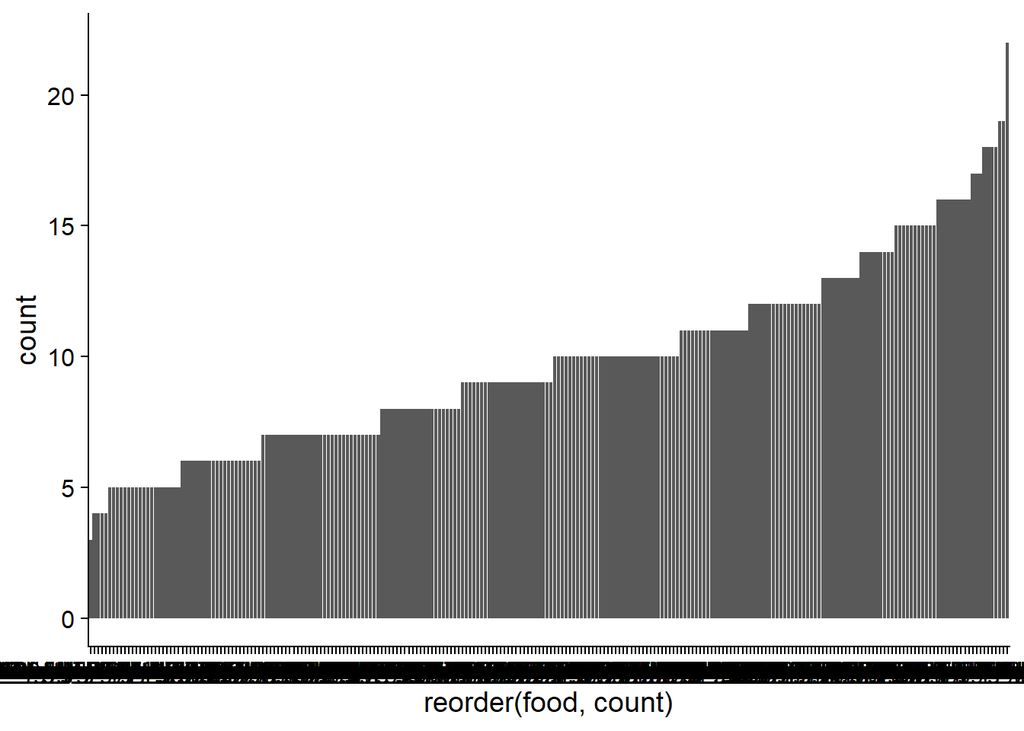

```r
# number of features per food and feature type
ggplot(
  data = working_file,
  aes(
    x = reorder(food, count),
    y = count
  )
) +
  geom_bar(
    stat = "identity"
  )
```

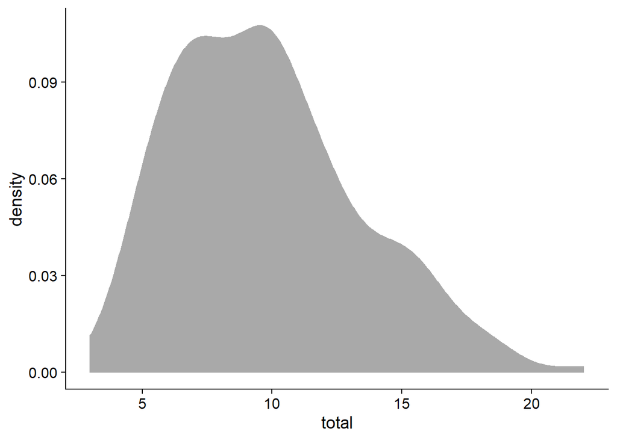

```r
# distribution of total features
ggplot(data = working_file %>% group_by(food) %>% slice(1),
       aes(
         x = total
       )) +
  geom_density(color = "darkgrey",
               fill = "darkgrey")
```

```r
# summary stats
working_file %>%
  group_by(food) %>%
  slice(1) %>%
  ungroup() %>%
  pull(total) %>%
  stat.desc()
```

```
##      nbr.val     nbr.null       nbr.na          min          max
##  240.0000000    0.0000000    0.0000000    3.0000000   22.0000000
##        range          sum       median         mean      SE.mean
##   19.0000000 2345.0000000    9.0000000    9.7708333    0.2292427
## CI.mean.0.95          var      std.dev     coef.var
##    0.4515943   12.6125349    3.5514131    0.3634708
```

```r
# number of foods per supermarket and food type
working_file %>%
  group_by(food) %>%
  slice(1) %>%
  ungroup() %>%
  with(.,
       table(
         supermarket,
         food_type
       ))
```

```
##            food_type
## supermarket meat_based vegan vegetarian
##           A         20    23         17
##           B         20    17         23
##           C         20    20         20
##           D         20    20         20
```

```r
describe_visualize(
  working_file,
  consumption_proportion,
  FALSE,
  TRUE
)
```

```
## [[1]]
##
##
##                           x
## -------------  ------------
## nbr.val         240.0000000
## nbr.null         84.0000000
## nbr.na            0.0000000
## min               0.0000000
## max               1.0000000
## range             1.0000000
## sum              29.3919968
## median            0.1000000
## mean              0.1224667
## SE.mean           0.0093009
## CI.mean.0.95      0.0183222
## var               0.0207615
## std.dev           0.1440886
## coef.var          1.1765541
##
## [[2]]
```

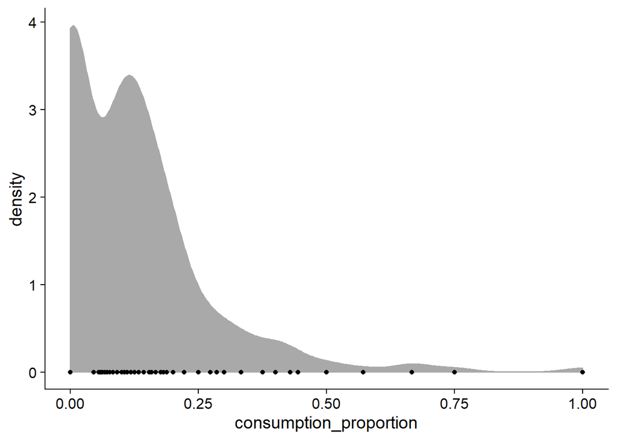

Similar picture for non-consupmtion situations, but with more mass toward the middle, reflected in higher mean.

```r
describe_visualize(
  working_file,
  non_consumption_proportion,
  FALSE,
  TRUE
)
```

```
## [[1]]
##
##
##                           x
## -------------  ------------
## nbr.val         240.0000000
## nbr.null         66.0000000
## nbr.na            0.0000000
## min               0.0000000
## max               0.6666667
## range             0.6666667
## sum              32.3616944
## median            0.1250000
## mean              0.1348404
## SE.mean           0.0077407
## CI.mean.0.95      0.0152487
## var               0.0143804
## std.dev           0.1199183
## coef.var          0.8893351
##
## [[2]]
```

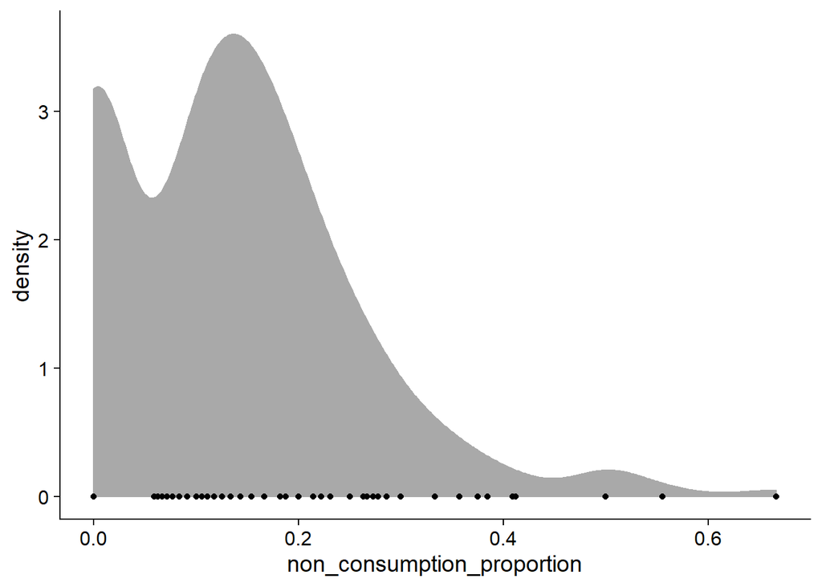

Situation-independent features have a different distribution with a strong left skew.

```r
describe_visualize(
  working_file,
  situation_independent_proportion,
  FALSE,
  TRUE
)
```

```
## [[1]]
##
##
##                           x
## -------------  ------------
## nbr.val         240.0000000
## nbr.null          2.0000000
## nbr.na            0.0000000
## min               0.0000000
## max               1.0000000
## range             1.0000000
## sum             178.2463089
## median            0.7777778
## mean              0.7426930
## SE.mean           0.0115319
## CI.mean.0.95      0.0227172
## var               0.0319166
## std.dev           0.1786521
## coef.var          0.2405463
##
## [[2]]
```

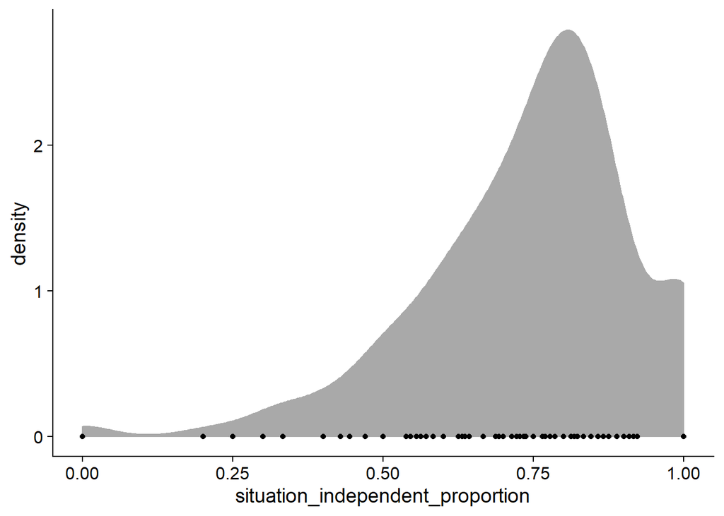

Last, I want to look at the three sub-categories of consumption features (negative immediate consequences didn’t have any features, which is why I leave it out from now on).

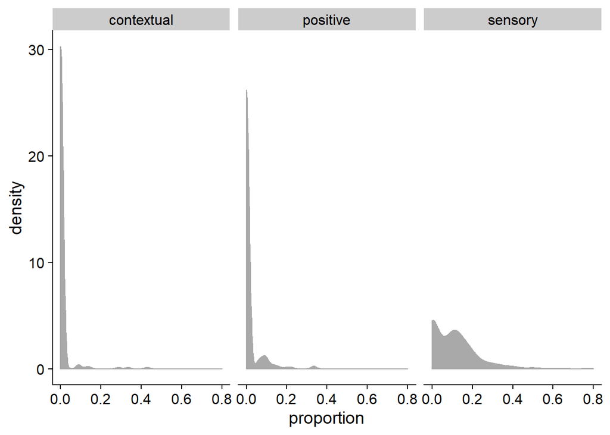

```r
working_file %>%
  # only select foods and the four sub-categories
  select(
    food_id,
    food,
    sensory_proportion,
    positive_proportion,
    contextual_proportion
  ) %>%
  group_by(food) %>%
  slice(1) %>%
  ungroup() %>%
  # turn into long format for faceting later
  pivot_longer(
    cols = c(-food_id, -food),
    names_to = c("feature_type", ".value"),
    names_sep = "_"
  ) %>%
  ggplot(
    aes(x = proportion)
  ) +
  geom_density(color = "darkgrey", fill = "darkgrey") +
  facet_wrap(~ feature_type)
```

Now per food type.

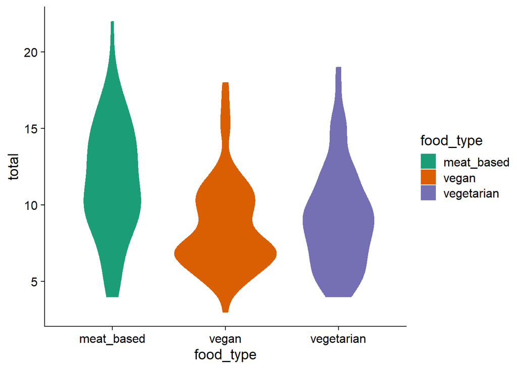

```r
three_violins(working_file, total)
```

```r
summary_stats(working_file, total)
```

```
## # A tibble: 3 x 3
##   food_type   mean    sd
##   <fct>      <dbl> <dbl>
## 1 meat_based 11.6   3.68
## 2 vegan       8.56  2.92
## 3 vegetarian  9.18  3.25
```

Alright, next I visualize the three main feature categories by food category, starting with consumption features.

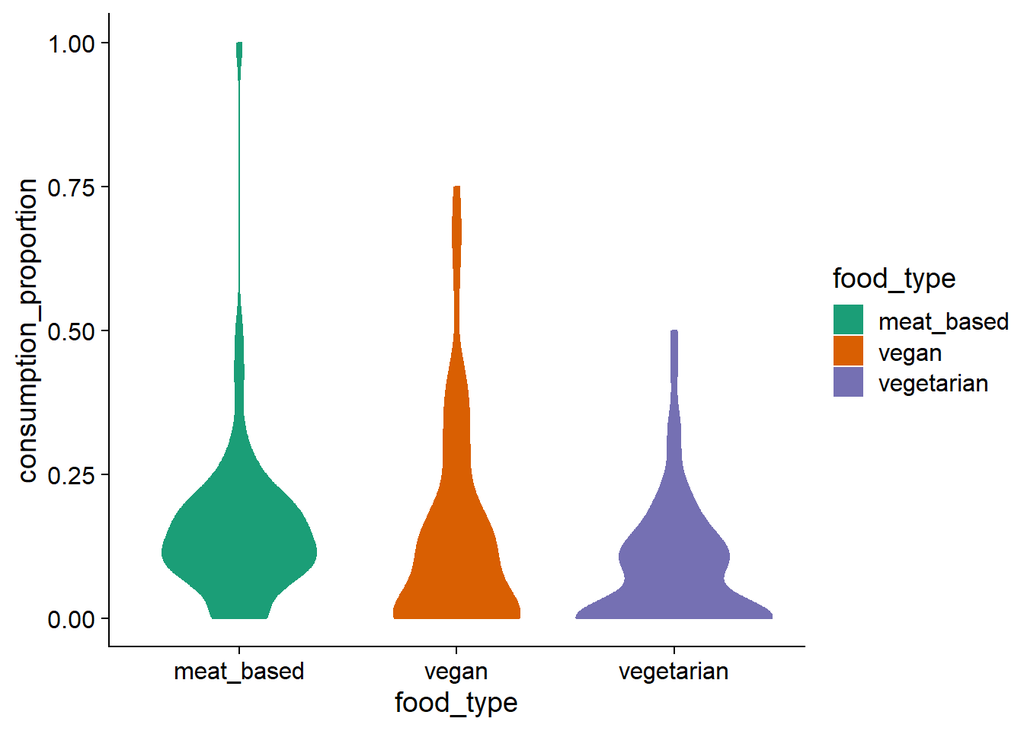

```r
three_violins(working_file, consumption_proportion)
```

```r
summary_stats(working_file, consumption_proportion)
```

```
## # A tibble: 3 x 3
##   food_type    mean    sd
##   <fct>       <dbl> <dbl>
## 1 meat_based 0.154  0.135
## 2 vegan      0.133  0.172
## 3 vegetarian 0.0805 0.105
```

Next non-consumption features.

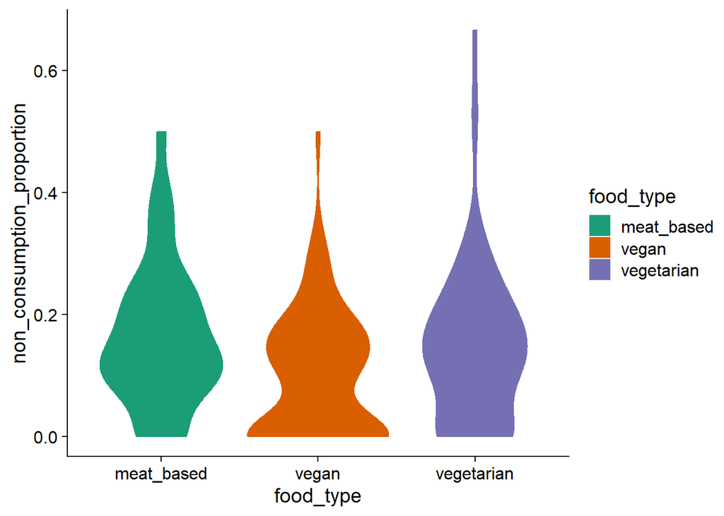

```r
three_violins(working_file, non_consumption_proportion)
```

```r
summary_stats(working_file, non_consumption_proportion)
```

```
## # A tibble: 3 x 3
##   food_type    mean    sd
##   <fct>       <dbl> <dbl>
## 1 meat_based 0.164  0.116
## 2 vegan      0.0971 0.104
## 3 vegetarian 0.143  0.128
```

Followed by situation-independent features.

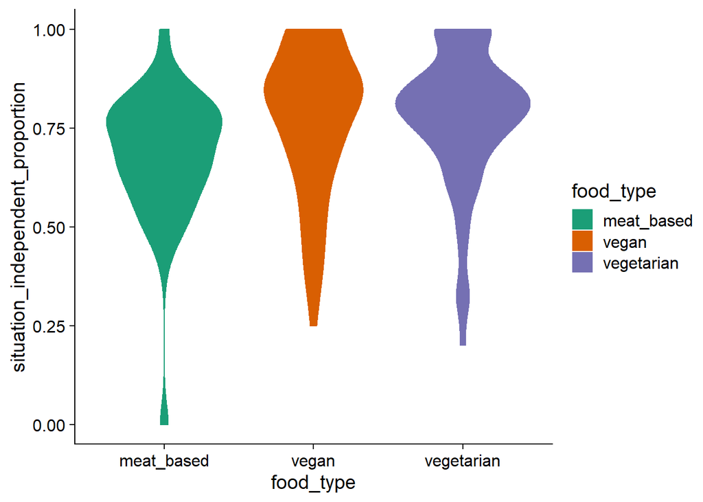

```r
three_violins(working_file, situation_independent_proportion)
```

```r
summary_stats(working_file, situation_independent_proportion)
```

```
## # A tibble: 3 x 3
##   food_type   mean    sd
##   <fct>      <dbl> <dbl>
## 1 meat_based 0.681 0.164
## 2 vegan      0.770 0.185
## 3 vegetarian 0.777 0.169
```

The same for the four sub-categories, starting with sensory and action features.

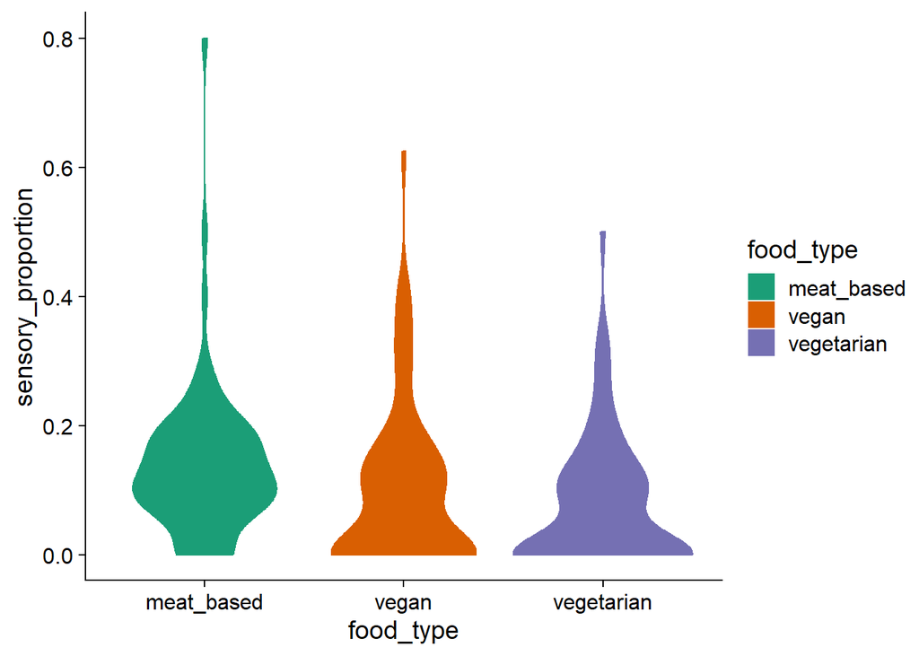

```r
three_violins(working_file, sensory_proportion)
```

```r
summary_stats(working_file, sensory_proportion)
```

```
## # A tibble: 3 x 3
##   food_type    mean    sd
##   <fct>       <dbl> <dbl>
## 1 meat_based 0.138  0.115
## 2 vegan      0.0962 0.125
## 3 vegetarian 0.0744 0.100
```

Next: Positive immediate consequences.

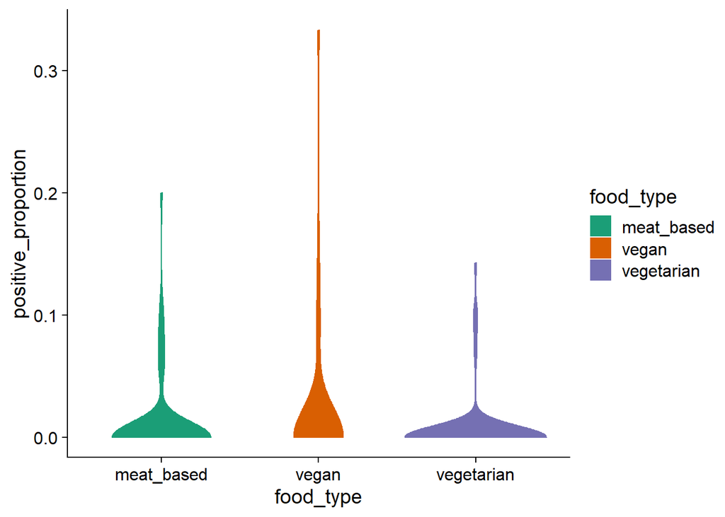

```r
three_violins(working_file, positive_proportion)
```

```r
summary_stats(working_file, positive_proportion)
```

```
## # A tibble: 3 x 3
##   food_type     mean     sd
##   <fct>        <dbl>  <dbl>
## 1 meat_based 0.0112  0.0331
## 2 vegan      0.0220  0.0648
## 3 vegetarian 0.00616 0.0247
```

Contexutal features.

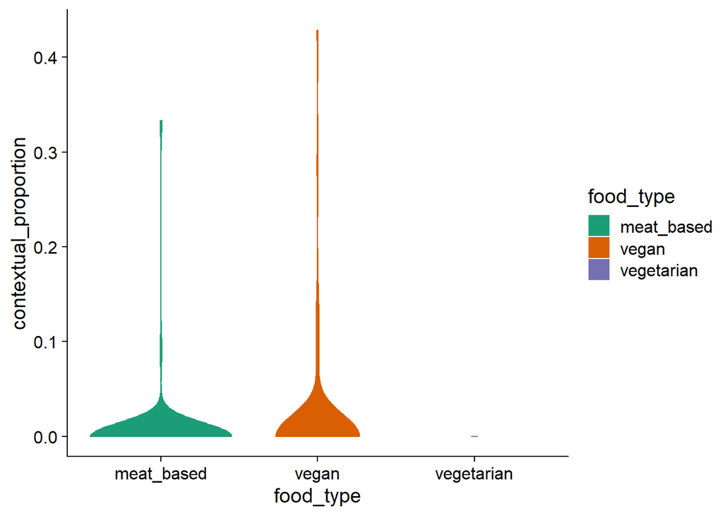

```r
three_violins(working_file, contextual_proportion)
```

```r
summary_stats(working_file, contextual_proportion)
```

```
## # A tibble: 3 x 3
##   food_type     mean     sd
##   <fct>        <dbl>  <dbl>
## 1 meat_based 0.00530 0.0383
## 2 vegan      0.0145  0.0612
## 3 vegetarian 0       0
```

Total features by supermarket show that we should take supermarket into account when running our models, as there are small differences in the total number of features between supermarkets.

```r
# summary stats
working_file %>%
  group_by(food) %>%
  slice(1) %>%
  group_by(supermarket) %>%
  summarize(
    mean = mean(total),
    sd = sd(total)
  )
```

```
## # A tibble: 4 x 3
##   supermarket  mean    sd
##   <chr>       <dbl> <dbl>
## 1 A            8.93  3.10
## 2 B           10.0   3.78
## 3 C            9.87  3.60
## 4 D           10.2   3.64
```

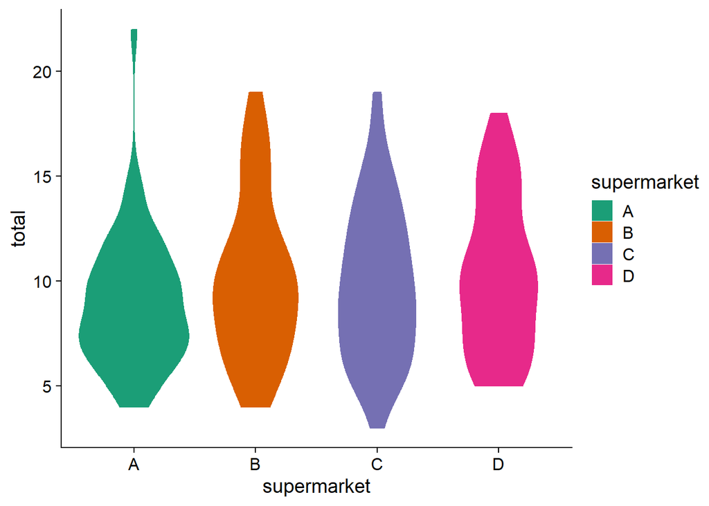

```r
# visualize
ggplot(
  working_file %>%
    group_by(food) %>%
    slice(1),
  aes(
    x = supermarket,
    y = total,
    color = supermarket,
    fill = supermarket
    )
) +
  geom_violin() +
  scale_color_brewer(palette = "Dark2") +
  scale_fill_brewer(palette = "Dark2")
```

When we only look at the proportion of sensory and action features, one supermarket stands out, again justifying that we include supermarket as random effect.

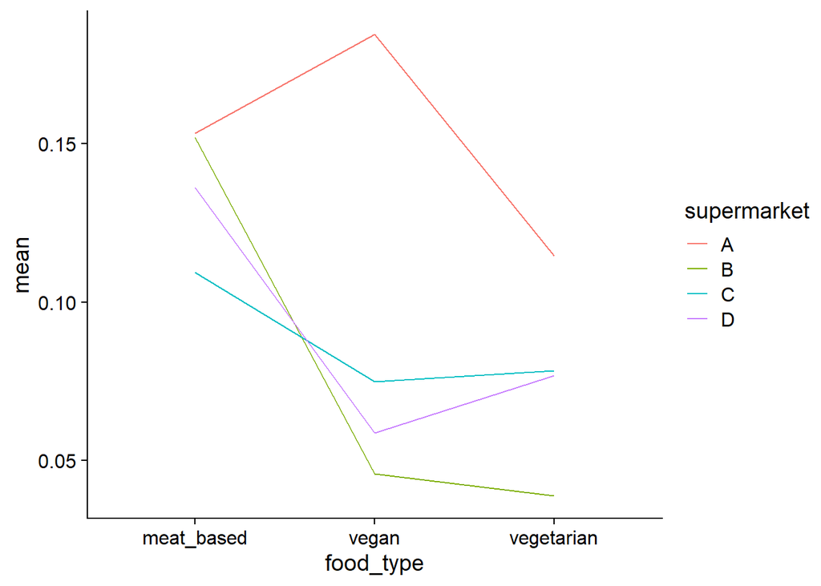

```r
# features by supermarket and food
sensory_supermarket <-
  working_file %>%
    group_by(food) %>%
    slice(1) %>%
    group_by(supermarket, food_type) %>%
    summarize(mean = mean(sensory_proportion))

# visualize
ggplot(
  sensory_supermarket,
  aes(
    x = food_type,
    y = mean,
    color = supermarket,
    group = supermarket
  )
) +
  geom_line()
```

# 3. Analysis

## 3.1 Confirmatory

Next, I see whether there are differences between the food categories on the proportions of features. We had one hypothesis: Meat-based foods will have more sensory and action features than vegan or vegetarian foods.

First: an analysis file that only contains one line per food.

```r
analysis_file <-
  working_file %>%
  group_by(food) %>%
  slice(1) %>%
  ungroup() %>%
  select(-feature) %>%
  arrange(food_id) %>%
  mutate(
    supermarket = as.factor(supermarket)
  )
```

We are analyzing proportions, meaning that a general linear model assuming a Gaussian distribution will most likely lead to biased effects. However, inspecting the proportions shows that most of them are following a binomial or beta distribution.

Moreover, we saw that there were differences in the total number of features between supermarkets, so I should take that into account in the analysis. I will therefore run a binomial model that includes a random intercept and slope per supermarket.

```r
# set contrasts
options(contrasts = c("contr.sum", "contr.poly"))

# check contrasts
contrasts(analysis_file$food_type)
```

```
##            [,1] [,2]
## meat_based    1    0
## vegan         0    1
## vegetarian   -1   -1
```

```r
# run model
sensory_model <-
  lme4::glmer(
    cbind(sensory_total, total-sensory_total) ~
      food_type +
      (1 + food_type | supermarket),
    data = analysis_file,
    family = binomial(logit)
  )

# summary
summary(sensory_model)
```

```
## Generalized linear mixed model fit by maximum likelihood (Laplace
##   Approximation) [glmerMod]
##  Family: binomial  ( logit )
## Formula: cbind(sensory_total, total - sensory_total) ~ food_type + (1 +
##     food_type | supermarket)
##    Data: analysis_file
##
##      AIC      BIC   logLik deviance df.resid
##    586.9    618.2   -284.4    568.9      231
##
## Scaled residuals:
##     Min      1Q  Median      3Q     Max
## -1.5225 -0.7172 -0.2524  0.6168  4.5575
##
## Random effects:
##  Groups      Name        Variance Std.Dev. Corr
##  supermarket (Intercept) 0.09487  0.3080
##              food_type1  0.08096  0.2845   -1.00
##              food_type2  0.07618  0.2760    1.00 -1.00
## Number of obs: 240, groups:  supermarket, 4
##
## Fixed effects:
##             Estimate Std. Error z value Pr(>|z|)
## (Intercept)  -2.3417     0.1729 -13.542   <2e-16 ***
## food_type1    0.4192     0.1722   2.434   0.0149 *
## food_type2   -0.2044     0.1833  -1.115   0.2647
## ---
## Signif. codes:  0 '***' 0.001 '**' 0.01 '*' 0.05 '.' 0.1 ' ' 1
##
## Correlation of Fixed Effects:
##            (Intr) fd_ty1
## food_type1 -0.834
## food_type2  0.740 -0.795
## convergence code: 0
## Model failed to converge with max|grad| = 0.00377414 (tol = 0.001, component 1)
```

```r
# approximate effect size
r.squaredGLMM(sensory_model)
```

```
##                     R2m        R2c
## theoretical 0.025031959 0.06680815
## delta       0.009798876 0.02615236
```

Next, I use the `DHARMA` package to inspect model diagnostics, which simulates new data for each observed data point and compares that density function to the observed value. Ideally, the distribution of the residuals is flat at 0.5.

The model diagnostics look really good, it doesn’t seem like there’s a need to worry about poor fit. One simulated value has a residual of 1, but the test is nonsignificant, meaning we probably don’t need to worry about outliers.

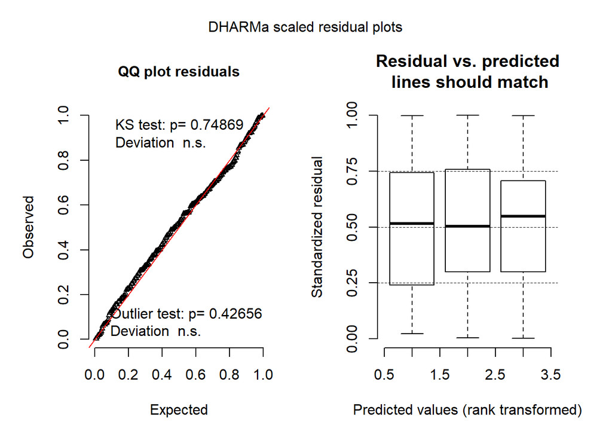

```r
# simulate residuals
sensory_residuals <- simulateResiduals(sensory_model, 1000)

# plot them
plot(sensory_residuals)
```

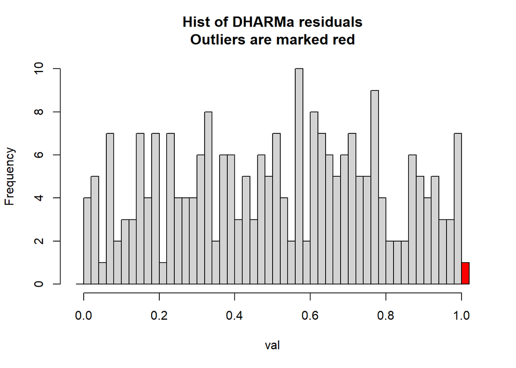

```
##
##  DHARMa outlier test based on exact binomial test
##
## data:  sensory_residuals
## outLow = 0.00e+00, outHigh = 1.00e+00, nobs = 2.40e+02, freqH0 =
## 9.99e-04, p-value = 0.4266
## alternative hypothesis: two.sided
```

```r
# check for outliers
testOutliers(sensory_residuals, plot = T)
```

Last, I check whether the differences between the three groups are singnificant. The overall effect misses the cut-off, and the pairwise comparisons show that only vegetarian and meat-based might differ. Note that I didn’t correct for pairwise comparison, because we only have one factor with three levels, see explanation [here](https://alexanderetz.com/2014/09/14/the-special-one-way-anova-or-shutting-up-reviewer-2/).

```r
# p-value with LRT
sensory_model_p <-
  mixed(
    cbind(sensory_total, total-sensory_total) ~
      food_type +
      (1 + food_type | supermarket),
    data = analysis_file,
    family = binomial(logit),
    method = "LRT"
  )
```

```
## Fitting 2 (g)lmer() models:
## [..]
```

```r
# summary
anova(sensory_model_p)
```

```
## Mixed Model Anova Table (Type 3 tests, LRT-method)
##
## Model: cbind(sensory_total, total - sensory_total) ~ food_type + (1 +
## Model:     food_type | supermarket)
## Data: analysis_file
## Df full model: 9
##           Df  Chisq Chi Df Pr(>Chisq)
## food_type  7 5.0069      2     0.0818 .
## ---
## Signif. codes:  0 '***' 0.001 '**' 0.01 '*' 0.05 '.' 0.1 ' ' 1
```

```r
# pairwise comparison
emmeans(sensory_model, pairwise ~ food_type, adj = c("none"))
```

```
## $emmeans
##  food_type  emmean     SE  df asymp.LCL asymp.UCL
##  meat_based  -1.92 0.0994 Inf     -2.12     -1.73
##  vegan       -2.55 0.3323 Inf     -3.20     -1.89
##  vegetarian  -2.56 0.2139 Inf     -2.98     -2.14
##
## Results are given on the logit (not the response) scale.
## Confidence level used: 0.95
##
## $contrasts
##  contrast                estimate    SE  df z.ratio p.value
##  meat_based - vegan        0.6236 0.337 Inf 1.852   0.0641
##  meat_based - vegetarian   0.6340 0.228 Inf 2.782   0.0054
##  vegan - vegetarian        0.0104 0.252 Inf 0.041   0.9671
##
## Results are given on the log odds ratio (not the response) scale.
```

## 3.2 Exploratory

### 3.2.1 Consumption

Next, I’d like to explore whether there are any differences between food types on the three main situation categories. Just like above, I’ll start with consumption features.

```r
# run model
consumption_model <-
  lme4::glmer(
    cbind(consumption_total, total-consumption_total) ~
      food_type +
      (1 + food_type | supermarket),
    data = analysis_file,
    family = binomial(logit)
  )

# summary
summary(consumption_model)
```

```
## Generalized linear mixed model fit by maximum likelihood (Laplace
##   Approximation) [glmerMod]
##  Family: binomial  ( logit )
## Formula:
## cbind(consumption_total, total - consumption_total) ~ food_type +
##     (1 + food_type | supermarket)
##    Data: analysis_file
##
##      AIC      BIC   logLik deviance df.resid
##    652.8    684.2   -317.4    634.8      231
##
## Scaled residuals:
##     Min      1Q  Median      3Q     Max
## -1.8724 -0.7794 -0.1795  0.5347  5.5324
##
## Random effects:
##  Groups      Name        Variance Std.Dev. Corr
##  supermarket (Intercept) 0.10354  0.3218
##              food_type1  0.08854  0.2976   -1.00
##              food_type2  0.12049  0.3471    1.00 -1.00
## Number of obs: 240, groups:  supermarket, 4
##
## Fixed effects:
##             Estimate Std. Error z value Pr(>|z|)
## (Intercept) -2.15313    0.17642 -12.204   <2e-16 ***
## food_type1   0.36014    0.17411   2.068   0.0386 *
## food_type2  -0.05994    0.20455  -0.293   0.7695
## ---
## Signif. codes:  0 '***' 0.001 '**' 0.01 '*' 0.05 '.' 0.1 ' ' 1
##
## Correlation of Fixed Effects:
##            (Intr) fd_ty1
## food_type1 -0.854
## food_type2  0.808 -0.842
## convergence code: 0
## boundary (singular) fit: see ?isSingular
```

```r
# approximate effect size
r.squaredGLMM(consumption_model)
```

```
##                     R2m        R2c
## theoretical 0.021132610 0.07031196
## delta       0.008318994 0.02767878
```

The model diagnostics look fine. The test for outliers barely passes the significance cut-off, but inspecting the actual plots shows that the model fits rather well.

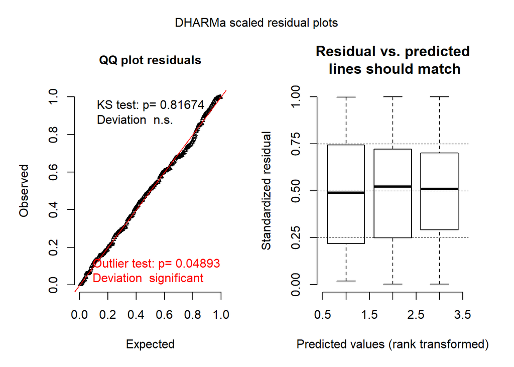

```r
# simulate residuals
consumption_residuals <- simulateResiduals(consumption_model, 1000)

# plot them
plot(consumption_residuals)
```

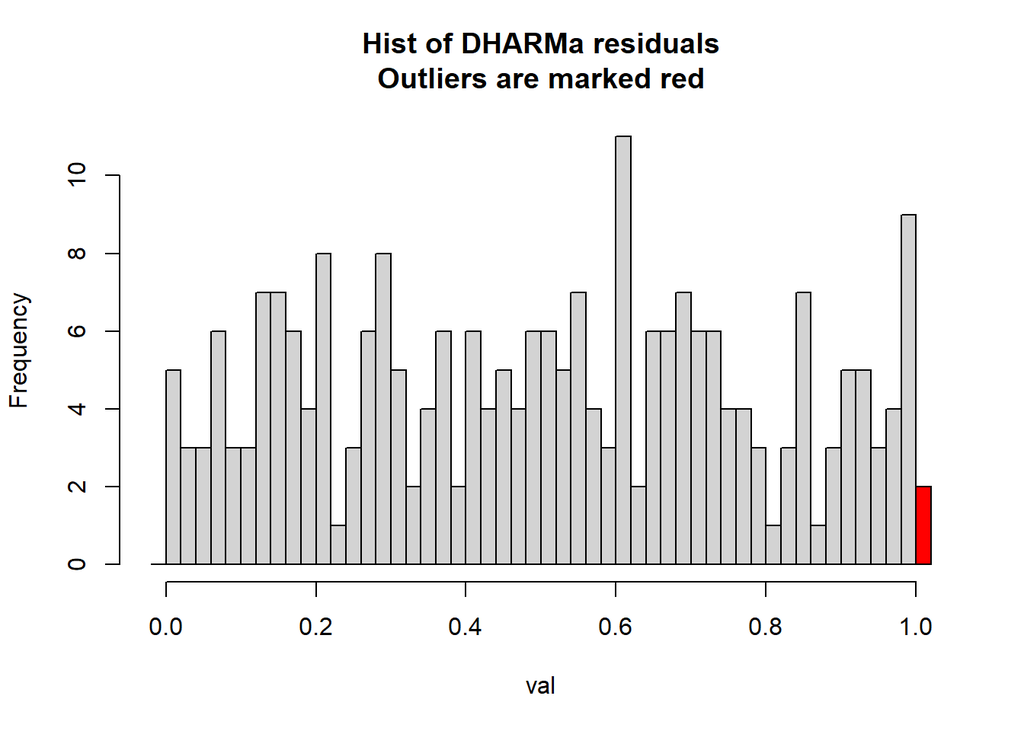

```
##
##  DHARMa outlier test based on exact binomial test
##
## data:  consumption_residuals
## outLow = 0.00e+00, outHigh = 2.00e+00, nobs = 2.40e+02, freqH0 =
## 9.99e-04, p-value = 0.04893
## alternative hypothesis: two.sided
```

```r
# check for outliers
testOutliers(consumption_residuals, plot = T)
```

Next, I inspect the p-value and pairwise comparisons. The overall effect is significant, again driven by highly significant difference between vegetarian and meat-based.

```r
# p-value with LRT
consumption_model_p <-
  mixed(
    cbind(consumption_total, total-consumption_total) ~
      food_type +
      (1 + food_type | supermarket),
    data = analysis_file,
    family = binomial(logit),
    method = "LRT"
  )
```

```
## Fitting 2 (g)lmer() models:
## [..]
```

```r
# summary
anova(consumption_model_p)
```

```
## Mixed Model Anova Table (Type 3 tests, LRT-method)
##
## Model: cbind(consumption_total, total - consumption_total) ~ food_type +
## Model:     (1 + food_type | supermarket)
## Data: analysis_file
## Df full model: 9
##           Df  Chisq Chi Df Pr(>Chisq)
## food_type  7 7.3109      2    0.02585 *
## ---
## Signif. codes:  0 '***' 0.001 '**' 0.01 '*' 0.05 '.' 0.1 ' ' 1
```

```r
# pairwise comparison
emmeans(consumption_model_p, pairwise ~ food_type, adj = c("none"))
```

```
## $emmeans
##  food_type  emmean     SE  df asymp.LCL asymp.UCL
##  meat_based  -1.79 0.0949 Inf     -1.98     -1.61
##  vegan       -2.21 0.3623 Inf     -2.92     -1.50
##  vegetarian  -2.45 0.1935 Inf     -2.83     -2.07
##
## Results are given on the logit (not the response) scale.
## Confidence level used: 0.95
##
## $contrasts
##  contrast                estimate    SE  df z.ratio p.value
##  meat_based - vegan          0.42 0.364 Inf 1.156   0.2478
##  meat_based - vegetarian     0.66 0.208 Inf 3.179   0.0015
##  vegan - vegetarian          0.24 0.279 Inf 0.862   0.3888
##
## Results are given on the log odds ratio (not the response) scale.
```

### 3.2.2 Non-consumption

I’ll continue with non-consumption features. The model converges without problems.

```r
# run model
non_consumption_model <-
  lme4::glmer(
    cbind(non_consumption_total, total-non_consumption_total) ~
      food_type +
      (1 + food_type | supermarket),
    data = analysis_file,
    family = binomial(logit)
  )

# summary
summary(non_consumption_model)
```

```
## Generalized linear mixed model fit by maximum likelihood (Laplace
##   Approximation) [glmerMod]
##  Family: binomial  ( logit )
## Formula: cbind(non_consumption_total, total - non_consumption_total) ~
##     food_type + (1 + food_type | supermarket)
##    Data: analysis_file
##
##      AIC      BIC   logLik deviance df.resid
##    695.0    726.4   -338.5    677.0      231
##
## Scaled residuals:
##     Min      1Q  Median      3Q     Max
## -1.8643 -0.8603 -0.1596  0.5301  5.0239
##
## Random effects:
##  Groups      Name        Variance  Std.Dev. Corr
##  supermarket (Intercept) 0.0117450 0.10837
##              food_type1  0.0004224 0.02055  -0.40
##              food_type2  0.0063671 0.07979  -0.78  0.88
## Number of obs: 240, groups:  supermarket, 4
##
## Fixed effects:
##             Estimate Std. Error z value Pr(>|z|)
## (Intercept) -1.82565    0.08252 -22.124  < 2e-16 ***
## food_type1   0.22527    0.08142   2.767  0.00566 **
## food_type2  -0.31952    0.10359  -3.084  0.00204 **
## ---
## Signif. codes:  0 '***' 0.001 '**' 0.01 '*' 0.05 '.' 0.1 ' ' 1
##
## Correlation of Fixed Effects:
##            (Intr) fd_ty1
## food_type1 -0.228
## food_type2 -0.028 -0.440
## convergence code: 0
## boundary (singular) fit: see ?isSingular
```

```r
# approximate effect size
r.squaredGLMM(non_consumption_model)
```

```
##                     R2m         R2c
## theoretical 0.016105302 0.021232827
## delta       0.006035871 0.007957541
```

The model diagnostics look fine again. The test for outliers passes the significance cut-off, but inspecting the actual plots shows that the model fits rather well.

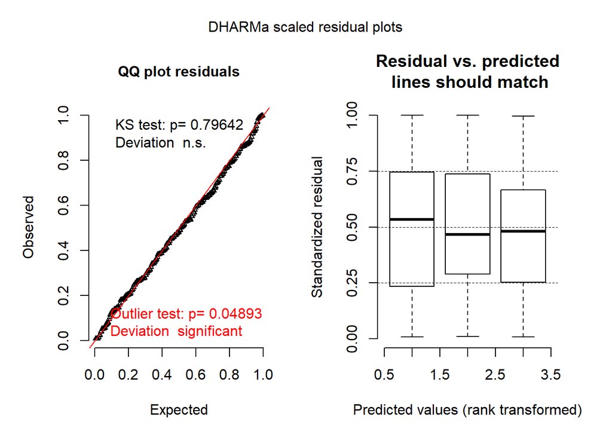

```r
# simulate residuals
non_consumption_residuals <- simulateResiduals(non_consumption_model, 1000)

# plot them
plot(non_consumption_residuals)
```

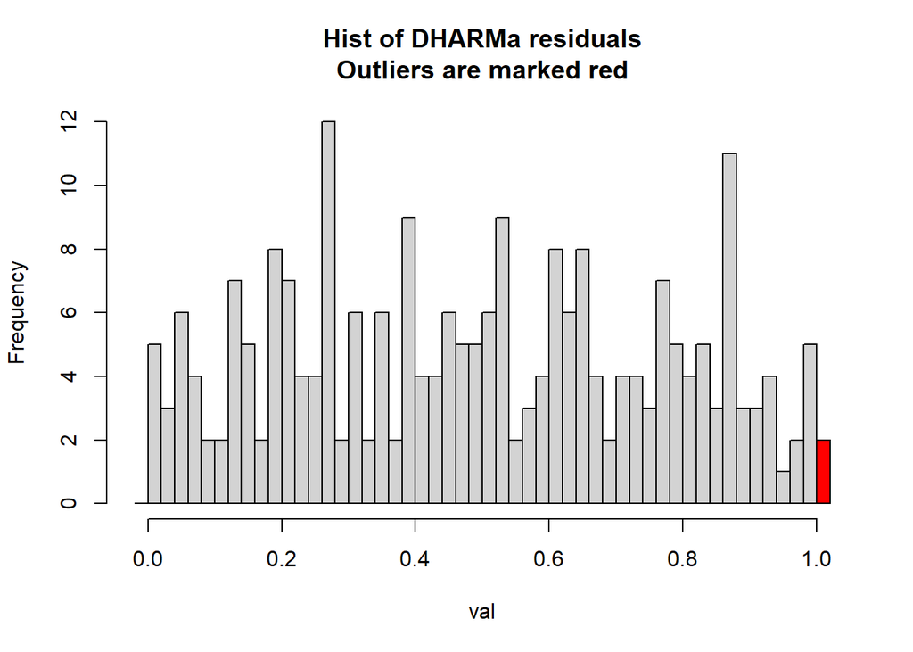

```
##
##  DHARMa outlier test based on exact binomial test
##
## data:  non_consumption_residuals
## outLow = 0.00e+00, outHigh = 2.00e+00, nobs = 2.40e+02, freqH0 =
## 9.99e-04, p-value = 0.04893
## alternative hypothesis: two.sided
```

```r
# check for outliers
testOutliers(non_consumption_residuals, plot = T)
```

Next, I inspect the p-value and pairwise comparisons. The overall effect is significant, driven by highly significant difference between vegan and meat-based. The difference between vegan and vegetarian is also significant.

```r
# p-value with LRT
non_consumption_model_p <-
  mixed(
    cbind(non_consumption_total, total-non_consumption_total) ~
      food_type +
      (1 + food_type | supermarket),
    data = analysis_file,
    family = binomial(logit),
    method = "LRT"
  )
```

```
## Fitting 2 (g)lmer() models:
## [..]
```

```r
# summary
anova(non_consumption_model_p)
```

```
## Mixed Model Anova Table (Type 3 tests, LRT-method)
##
## Model: cbind(non_consumption_total, total - non_consumption_total) ~
## Model:     food_type + (1 + food_type | supermarket)
## Data: analysis_file
## Df full model: 9
##           Df  Chisq Chi Df Pr(>Chisq)
## food_type  7 7.5048      2    0.02346 *
## ---
## Signif. codes:  0 '***' 0.001 '**' 0.01 '*' 0.05 '.' 0.1 ' ' 1
```

```r
# pairwise comparison
emmeans(non_consumption_model_p, pairwise ~ food_type, adj = c("none"))
```

```
## $emmeans
##  food_type  emmean    SE  df asymp.LCL asymp.UCL
##  meat_based  -1.60 0.102 Inf     -1.80     -1.40
##  vegan       -2.15 0.131 Inf     -2.40     -1.89
##  vegetarian  -1.73 0.142 Inf     -2.01     -1.45
##
## Results are given on the logit (not the response) scale.
## Confidence level used: 0.95
##
## $contrasts
##  contrast                estimate    SE  df z.ratio p.value
##  meat_based - vegan         0.545 0.157 Inf  3.460  0.0005
##  meat_based - vegetarian    0.131 0.150 Inf  0.876  0.3812
##  vegan - vegetarian        -0.414 0.186 Inf -2.221  0.0263
##
## Results are given on the log odds ratio (not the response) scale.
```

### 3.2.3 Situation independent

I’ll continue with situation-independent features. The model converges without problems.

```r
# run model
situation_independent_model <-
  lme4::glmer(
    cbind(situation_independent_total, total-situation_independent_total) ~
      food_type +
      (1 + food_type | supermarket),
    data = analysis_file,
    family = binomial(logit)
  )

# summary
summary(situation_independent_model)
```

```
## Generalized linear mixed model fit by maximum likelihood (Laplace
##   Approximation) [glmerMod]
##  Family: binomial  ( logit )
## Formula:
## cbind(situation_independent_total, total - situation_independent_total) ~
##     food_type + (1 + food_type | supermarket)
##    Data: analysis_file
##
##      AIC      BIC   logLik deviance df.resid
##    839.1    870.4   -410.6    821.1      231
##
## Scaled residuals:
##     Min      1Q  Median      3Q     Max
## -5.2334 -0.5276  0.1539  0.7483  2.0261
##
## Random effects:
##  Groups      Name        Variance Std.Dev. Corr
##  supermarket (Intercept) 0.06839  0.2615
##              food_type1  0.01956  0.1399   -1.00
##              food_type2  0.05272  0.2296    0.99 -0.99
## Number of obs: 240, groups:  supermarket, 4
##
## Fixed effects:
##             Estimate Std. Error z value Pr(>|z|)
## (Intercept)   1.1051     0.1400   7.892 2.96e-15 ***
## food_type1   -0.3137     0.0953  -3.292 0.000995 ***
## food_type2    0.2242     0.1376   1.630 0.103107
## ---
## Signif. codes:  0 '***' 0.001 '**' 0.01 '*' 0.05 '.' 0.1 ' ' 1
##
## Correlation of Fixed Effects:
##            (Intr) fd_ty1
## food_type1 -0.747
## food_type2  0.812 -0.793
## convergence code: 0
## boundary (singular) fit: see ?isSingular
```

```r
# approximate effect size
r.squaredGLMM(situation_independent_model)
```

```
##                    R2m        R2c
## theoretical 0.01526030 0.04298198
## delta       0.01121378 0.03158459
```

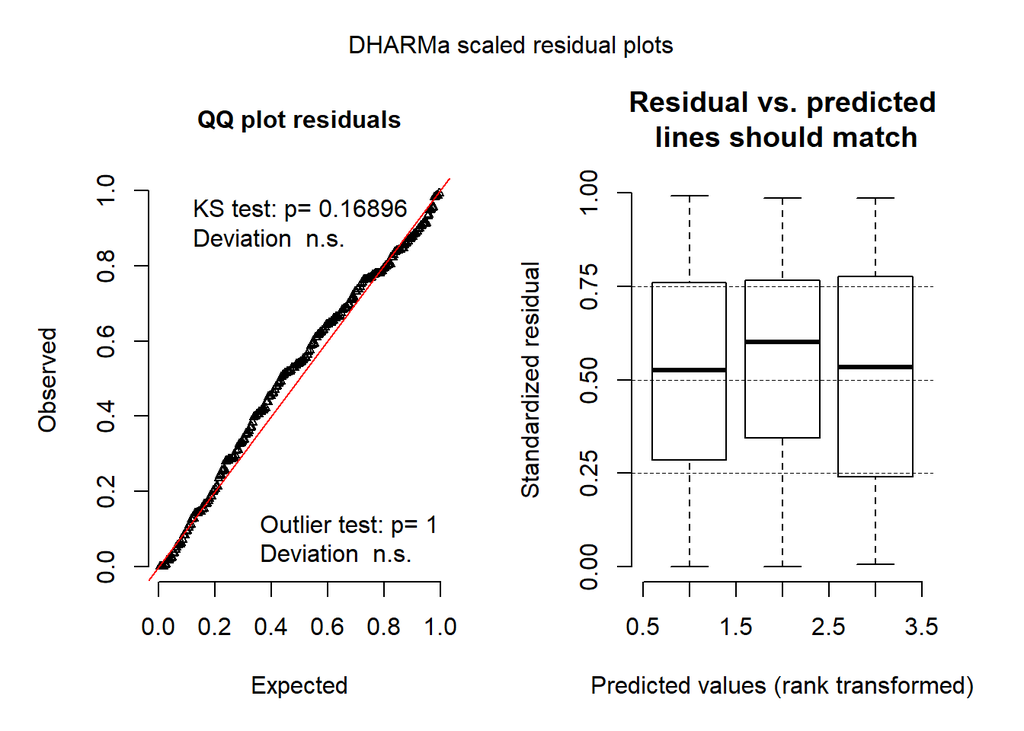

```r
# simulate residuals
situation_independent_residuals <- simulateResiduals(situation_independent_model, 1000)

# plot them
plot(situation_independent_residuals)
```

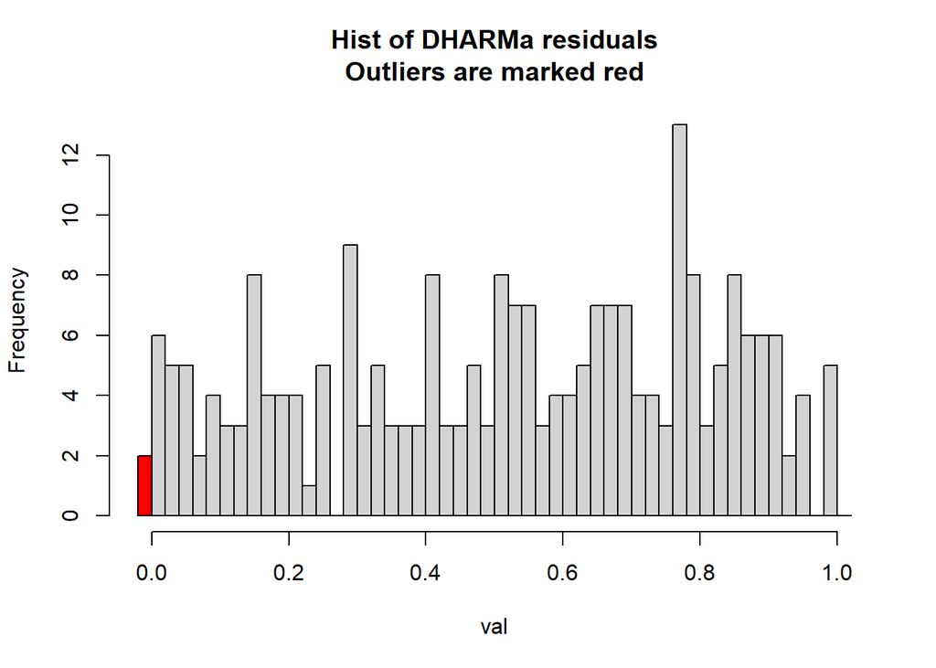

```
##
##  DHARMa outlier test based on exact binomial test
##
## data:  situation_independent_residuals
## outLow = 2.00e+00, outHigh = 0.00e+00, nobs = 2.40e+02, freqH0 =
## 9.99e-04, p-value = 1
## alternative hypothesis: two.sided
```

```r
# check for outliers
testOutliers(situation_independent_residuals, plot = T)
```

Next, I inspect the p-value and pairwise comparisons. The overall effect is barely significant, driven by highly significant difference between vegetarian and meat-based foods; the difference between vegan and meat-based is also significant.

```r
# p-value with LRT
situation_independent_model_p <-
  mixed(
    cbind(situation_independent_total, total-situation_independent_total) ~
      food_type +
      (1 + food_type | supermarket),
    data = analysis_file,
    family = binomial(logit),
    method = "LRT"
  )
```

```
## Fitting 2 (g)lmer() models:
## [..]
```

```r
# summary
anova(situation_independent_model_p)
```

```
## Mixed Model Anova Table (Type 3 tests, LRT-method)
##
## Model: cbind(situation_independent_total, total - situation_independent_total) ~
## Model:     food_type + (1 + food_type | supermarket)
## Data: analysis_file
## Df full model: 9
##           Df  Chisq Chi Df Pr(>Chisq)
## food_type  7 6.7972      2    0.03342 *
## ---
## Signif. codes:  0 '***' 0.001 '**' 0.01 '*' 0.05 '.' 0.1 ' ' 1
```

```r
# pairwise comparison
emmeans(situation_independent_model_p, pairwise ~ food_type, adj = c("none"))
```

```
## $emmeans
##  food_type  emmean     SE  df asymp.LCL asymp.UCL
##  meat_based  0.791 0.0936 Inf     0.608     0.975
##  vegan       1.329 0.2642 Inf     0.811     1.847
##  vegetarian  1.195 0.1244 Inf     0.951     1.438
##
## Results are given on the logit (not the response) scale.
## Confidence level used: 0.95
##
## $contrasts
##  contrast                estimate    SE  df z.ratio p.value
##  meat_based - vegan        -0.538 0.221 Inf -2.435  0.0149
##  meat_based - vegetarian   -0.403 0.117 Inf -3.448  0.0006
##  vegan - vegetarian         0.135 0.208 Inf  0.648  0.5168
##
## Results are given on the log odds ratio (not the response) scale.
```

# 4. Write files

Last, I write the analysis files.

```r
write_csv(analysis_file, here("data", "study1", "analysis_file.csv"))
```